```python
%matplotlib inline
import json
import numpy as np
from scipy.stats import norm
import pandas as pd
import statistics
from scipy.stats import gamma
from scipy.stats import binom
from scipy.stats import expon
from scipy.stats import poisson
from scipy.interpolate import make_interp_spline
import seaborn as sns
import matplotlib.pyplot as plt
from matplotlib.ticker import StrMethodFormatter
import seaborn as sns; sns.set()
from numpy import hstack
from numpy import  asarray
from numpy import exp
from sklearn.neighbors import KernelDensity
import re
from operator import itemgetter
from scipy import special
from scipy.stats import t
from scipy import stats
import ast
```

# Μηνάς Ελευθερίου ΑΜ:4245 Data Mining - Lab1

# Ερώτηση 1

# Α.1

1)O reservoir sampling κρατάει χωρό για Κ αντικείμενα και ένα μετρητή με τον αριθμό των αντικειμένων Ν.

2)Διατρέχει τα αντικείμενα ένα-ένα όπως έρχονται από το ρεύμα και επιλέγει τα πρώτα Κ.

3)Συνεχίζοντας να διατρέχει το ρεύμα απο το Κ+1 στοιχείο και για καθέ ενα μέχρι το τέλος:

```
-επιλέγει καθέ φορά εναν τυχαίο αριθμό j
-ελέγχει αν είναι μικρότερος απο το Κ. Εάν ναι τότε απο τα επιλεγμένα K αντικείμενα αντικαταστά το j-ιστό αντικείμενο με το αντικείμενο j.
```

4)Στο τελικό χώρο για Κ αντικείμενα βρίσκονται αντικείμενα που το κάθε ένα επιλέχτηκε με πιθανότητα Κ/Ν

# 2.

Για να αποδείξουμε ότι αυτή η λύση λειτουργεί, πρέπει να αποδείξουμε ότι η πιθανότητα ότι οποιοδήποτε ρεύμα στοιχείου[i]όπου 0 <= i < n θα βρίσκεται στον τελικό χώρο είναι k/n Τα πρώτα στοιχεία k αντιγράφονται αρχικά μπορούν να αφαιρεθούν αργότερα σε επαναλήψεις για ρεύμα[k] στο ρεύμα[n]. Η πιθανότητα ότι ένα στοιχείο από το ρεύμα βρίσκεται στον τελικό πίνακα = Πιθανότητα να μην επιλεγεί το στοιχείο όταν τα στοιχεία μεταδίδουν[k], ρεύμα[k+1], .... ρεύμα[n-1] θεωρούνται =[k/(k+1)] x [(k+1)/(k+2)] x [(k+2)/(k+3)] x ... x [(n-1)/n] = κ/n

# 3.

```python
import random
import os

def reservoir_sampling(filename, k):
    results = []
    with open(filename) as f:
        for n, line in enumerate(f):
            if n < k:
                results.append(line.rstrip())
            else:
                r = random.randint(0, n)
                if r < k:
                    results[r] = line.rstrip()
    return results
```

```python
filename = "input.txt"
k = 10;
reservoir_sampling(filename, k)
```

```
['Bruno Caboclo',
 'Cory Joseph',
 'Kelly Oubre Jr.',
 'Wesley Johnson',
 'Cheick Diallo',
 'Reggie Williams',
 'Mike James',
 'Marcin Gortat',
 'Deng Adel',
 'Ike Diogu']
```

B.

for item, weight in inputs: if weight == 0: continue total += weight if random() < weight/total: selected = item

# Ερώτηση 2

# Απο την πιο κάτω εξερεύνηση παρατηρούμε οτι οι συναρτήσεις fb και fc είναι εκθετικές

```python
df = pd.read_csv('data.csv')
```

```python
df
```

|  | A | B | C |
| --- | --- | --- | --- |
| 0 | 6.505578 | 66.172129 | 19.716079 |
| 1 | 5.377777 | 30.776221 | 13.266301 |
| 2 | 6.013127 | 51.259341 | 12.369112 |
| 3 | 8.895367 | 97.515747 | 37.422531 |
| 4 | 6.595621 | 46.565423 | 18.591031 |
| ... | ... | ... | ... |
| 995 | 9.720134 | 135.428506 | 70.556928 |
| 996 | 7.396528 | 58.934710 | 23.238011 |
| 997 | 4.723997 | 40.772307 | 8.338360 |
| 998 | 2.273415 | 6.610219 | 3.086192 |
| 999 | 7.156786 | 84.881706 | 20.930456 |

1000 rows × 3 columns

```python
df.describe()
```

|  | A | B | C |
| --- | --- | --- | --- |
| count | 1000.000000 | 1000.000000 | 1000.000000 |
| mean | 4.989325 | 50.132540 | 17.575354 |
| std | 2.943642 | 47.220768 | 18.910880 |
| min | 0.023342 | 0.000698 | 1.028125 |
| 25% | 2.454190 | 9.033817 | 3.365123 |
| 50% | 4.881978 | 35.622529 | 8.846691 |
| 75% | 7.570352 | 83.466044 | 26.318362 |
| max | 9.994084 | 189.644837 | 82.750898 |

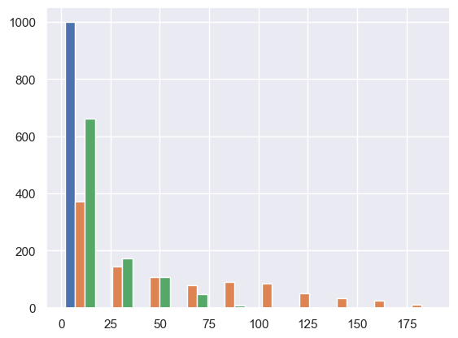

```python
ax = plt.hist(df)
```

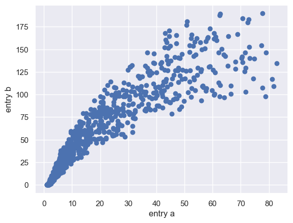

```python
plt.scatter(df['C'], df['B'])
plt.xlabel('entry a')
plt.ylabel('entry b')
plt.show()
```

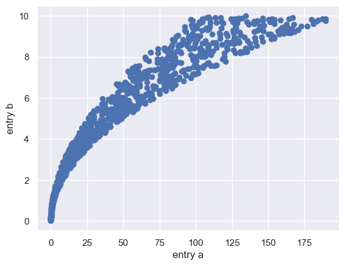

```python
plt.scatter(df['B'], df['A'])
plt.xlabel('entry a')
plt.ylabel('entry b')
plt.show()
```

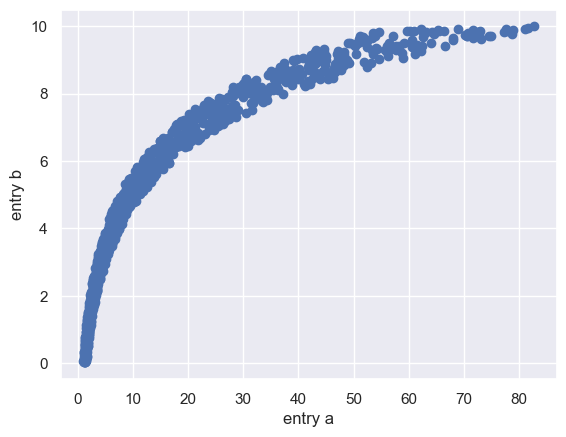

```python
plt.scatter(df['C'], df['A'])
plt.xlabel('entry a')
plt.ylabel('entry b')
plt.show()
```

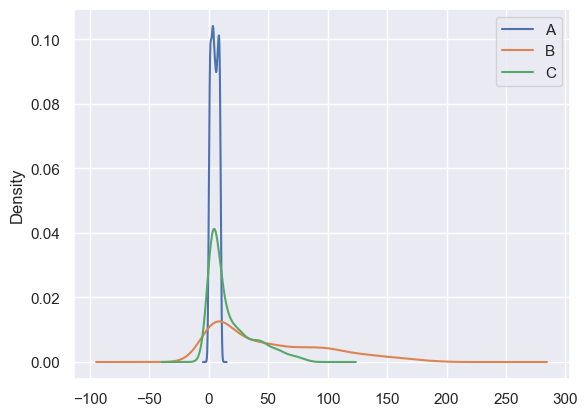

```python
ax = df.plot.kde()
```

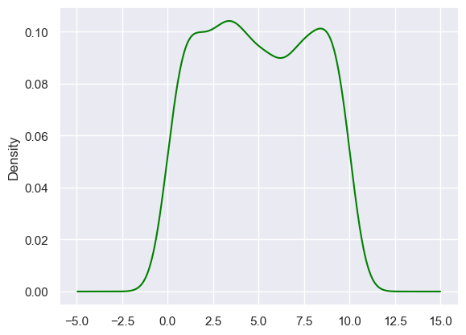

```python
df['A'].plot.kde(color='green')
plt.show()
```

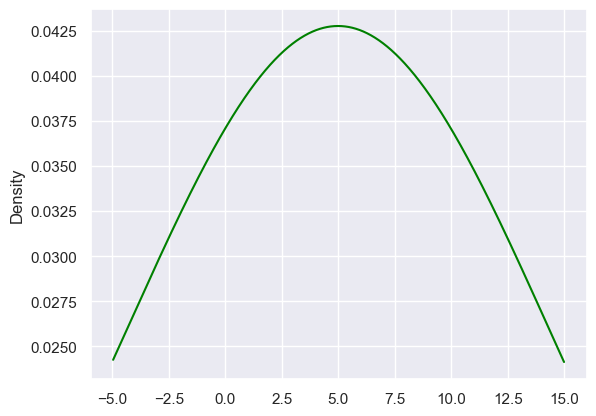

```python
df['A'].plot.kde(color='green',bw_method=3)
plt.show()
```

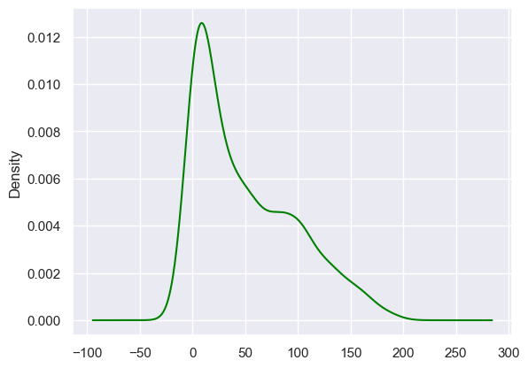

```python
df['B'].plot.kde(color='green')
plt.show()
```

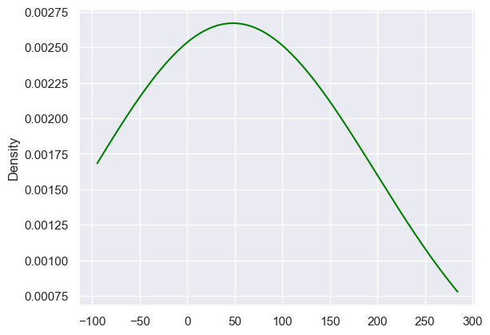

```python
df['B'].plot.kde(color='green',bw_method=3)
plt.show()
```

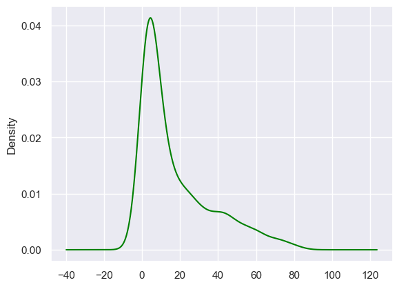

```python
df['C'].plot.kde(color='green')
plt.show()
```

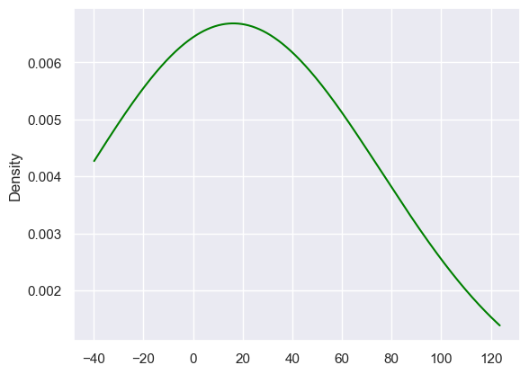

```python
df['C'].plot.kde(color='green',bw_method=3)
plt.show()
```

```python
import scipy.stats as st
def get_best_distribution(data):
    dist_names = ["norm", "exponweib", "weibull_max", "weibull_min", "pareto", "genextreme"]
    dist_results = []
    params = {}
    for dist_name in dist_names:
        dist = getattr(st, dist_name)
        param = dist.fit(data)

        params[dist_name] = param
        # Applying the Kolmogorov-Smirnov test
        D, p = st.kstest(data, dist_name, args=param)
        print("p value for "+dist_name+" = "+str(p))
        dist_results.append((dist_name, p))

    # select the best fitted distribution
    best_dist, best_p = (max(dist_results, key=lambda item: item[1]))
    # store the name of the best fit and its p value

    print("Best fitting distribution: "+str(best_dist))
    print("Best p value: "+ str(best_p))
    print("Parameters for the best fit: "+ str(params[best_dist]))

    return best_dist, best_p, params[best_dist]
```

```python
get_best_distribution(df['A'])
```

```
p value for norm = 0.00011863507231223924
p value for exponweib = 0.0007028800944603632
p value for weibull_max = 2.298268031470754e-05
p value for weibull_min = 8.331233236552734e-110
p value for pareto = 1.2322315369958911e-20
p value for genextreme = 2.2973347116886516e-05
Best fitting distribution: exponweib
Best p value: 0.0007028800944603632
Parameters for the best fit: (0.08472116407124855, 11.18686812277332, 0.023341835791869676, 9.48734218330161)
```

```
('exponweib',
 0.0007028800944603632,
 (0.08472116407124855,
  11.18686812277332,
  0.023341835791869676,
  9.48734218330161))
```

```python
get_best_distribution(df['B'])
```

```
p value for norm = 1.4081034614068396e-18
p value for exponweib = 2.7215897421526485e-15
p value for weibull_max = 0.0
p value for weibull_min = 8.577017175554746e-261
p value for pareto = 1.8221177015915896e-09
p value for genextreme = 3.128682598919374e-09
Best fitting distribution: genextreme
Best p value: 3.128682598919374e-09
Parameters for the best fit: (-0.6804566229037148, 18.41066956422992, 23.44883506714661)
```

```
('genextreme',
 3.128682598919374e-09,
 (-0.6804566229037148, 18.41066956422992, 23.44883506714661))
```

```python
get_best_distribution(df['C'])
```

```
p value for norm = 2.558028366434558e-32
```

```
p value for exponweib = 0.005801104830980186
p value for weibull_max = 0.0
p value for weibull_min = 6.034333332289758e-25
p value for pareto = 7.932268097438335e-06
p value for genextreme = 1.3241708014072749e-06
Best fitting distribution: exponweib
Best p value: 0.005801104830980186
Parameters for the best fit: (1.3357731431606064, 0.6612206503743447, 1.0281253327599322, 10.195241522811548)
```

```
('exponweib',
 0.005801104830980186,
 (1.3357731431606064,
  0.6612206503743447,
  1.0281253327599322,
  10.195241522811548))
```

# Ερώτηση 3

# ΠΡΟΕΤΟΙΜΑΣΙΑ

```python
business = pd.read_json('yelp_academic_dataset_business.json',lines=True , chunksize= 100)
```

```python
for r in business:
    subset = r
    break
```

```python
subset.shape
```

```
(100, 14)
```

```python
subset.dtypes
```

```
business_id      object
name             object
address          object
city             object
state            object
postal_code      object
latitude        float64
longitude       float64
stars           float64
review_count      int64
is_open           int64
attributes       object
categories       object
hours            object
dtype: object
```

```python
subset.head(10)
```

|  | business_id | name | address | city | state | postal_code | latitude | longitude | stars | review_count | is_open | attributes | categories | hours |
| --- | --- | --- | --- | --- | --- | --- | --- | --- | --- | --- | --- | --- | --- | --- |
| 0 | Pns2l4eNsfO8kk83dixA6A | Abby Rappoport, LAC, CMQ | 1616 Chapala St, Ste 2 | Santa Barbara | CA | 93101 | 34.426679 | -119.711197 | 5.0 | 7 | 0 | {'ByAppointmentOnly': 'True'} | Doctors, Traditional Chinese Medicine, Naturop... | None |
| 1 | mpf3x-BjTdTEA3yCZrAYPw | The UPS Store | 87 Grasso Plaza Shopping Center | Affton | MO | 63123 | 38.551126 | -90.335695 | 3.0 | 15 | 1 | {'BusinessAcceptsCreditCards': 'True'} | Shipping Centers, Local Services, Notaries, Ma... | {'Monday': '0:0-0:0', 'Tuesday': '8:0-18:30', ... |
| 2 | tUFrWirKiKi_TAnsVWINQQ | Target | 5255 E Broadway Blvd | Tucson | AZ | 85711 | 32.223236 | -110.880452 | 3.5 | 22 | 0 | {'BikeParking': 'True', 'BusinessAcceptsCredit... | Department Stores, Shopping, Fashion, Home & G... | {'Monday': '8:0-22:0', 'Tuesday': '8:0-22:0', ... |
| 3 | MTSW4McQd7CbVtyjqoe9mw | St Honore Pastries | 935 Race St | Philadelphia | PA | 19107 | 39.955505 | -75.155564 | 4.0 | 80 | 1 | {'RestaurantsDelivery': 'False', 'OutdoorSeati... | Restaurants, Food, Bubble Tea, Coffee & Tea, B... | {'Monday': '7:0-20:0', 'Tuesday': '7:0-20:0', ... |
| 4 | mWMc6_wTdE0EUBKIGXDVfA | Perkiomen Valley Brewery | 101 Walnut St | Green Lane | PA | 18054 | 40.338183 | -75.471659 | 4.5 | 13 | 1 | {'BusinessAcceptsCreditCards': 'True', 'Wheelc... | Brewpubs, Breweries, Food | {'Wednesday': '14:0-22:0', 'Thursday': '16:0-2... |
| 5 | CF33F8-E6oudUQ46HnavjQ | Sonic Drive-In | 615 S Main St | Ashland City | TN | 37015 | 36.269593 | -87.058943 | 2.0 | 6 | 1 | {'BusinessParking': 'None', 'BusinessAcceptsCr... | Burgers, Fast Food, Sandwiches, Food, Ice Crea... | {'Monday': '0:0-0:0', 'Tuesday': '6:0-22:0', '... |
| 6 | n_0UpQx1hsNbnPUSlodU8w | Famous Footwear | 8522 Eager Road, Dierbergs Brentwood Point | Brentwood | MO | 63144 | 38.627695 | -90.340465 | 2.5 | 13 | 1 | {'BusinessAcceptsCreditCards': 'True', 'Restau... | Sporting Goods, Fashion, Shoe Stores, Shopping... | {'Monday': '0:0-0:0', 'Tuesday': '10:0-18:0', ... |
| 7 | qkRM_2X51Yqxk3btlwAQIg | Temple Beth-El | 400 Pasadena Ave S | St. Petersburg | FL | 33707 | 27.766590 | -82.732983 | 3.5 | 5 | 1 | None | Synagogues, Religious Organizations | {'Monday': '9:0-17:0', 'Tuesday': '9:0-17:0', ... |
| 8 | k0hlBqXX-Bt0vf1op7Jr1w | Tsevi's Pub And Grill | 8025 Mackenzie Rd | Affton | MO | 63123 | 38.565165 | -90.321087 | 3.0 | 19 | 0 | {'Caters': 'True', 'Alcohol': 'u'full_bar'', '... | Pubs, Restaurants, Italian, Bars, American (Tr... | None |
| 9 | bBDDEgkFA1Otx9Lfe7BZUQ | Sonic Drive-In | 2312 Dickerson Pike | Nashville | TN | 37207 | 36.208102 | -86.768170 | 1.5 | 10 | 1 | {'RestaurantsAttire': ''casual'', 'Restaurants... | Ice Cream & Frozen Yogurt, Fast Food, Burgers,... | {'Monday': '0:0-0:0', 'Tuesday': '6:0-21:0', '... |

```python
business = pd.read_json('yelp_academic_dataset_business.json', lines=True, encoding='utf-8')
```

```python
business.shape
```

```
(150346, 14)
```

```python
ndf = business.dropna()
```

```python
ndf.shape
```

```
(117618, 14)
```

```python
ndf = ndf[ndf['city'].str.contains("Philadelphia")]
```

```python
ndf.shape
```

```
(11075, 14)
```

```python
ndf.dropna(axis=0, how='any', thresh=None, subset=None, inplace=False)
```

|  | business_id | name | address | city | state | postal_code | latitude | longitude | stars | review_count | is_open | attributes | categories | hours |
| --- | --- | --- | --- | --- | --- | --- | --- | --- | --- | --- | --- | --- | --- | --- |
| 3 | MTSW4McQd7CbVtyjqoe9mw | St Honore Pastries | 935 Race St | Philadelphia | PA | 19107 | 39.955505 | -75.155564 | 4.0 | 80 | 1 | {'RestaurantsDelivery': 'False', 'OutdoorSeati... | Restaurants, Food, Bubble Tea, Coffee & Tea, B... | {'Monday': '7:0-20:0', 'Tuesday': '7:0-20:0', ... |
| 15 | MUTTqe8uqyMdBl186RmNeA | Tuna Bar | 205 Race St | Philadelphia | PA | 19106 | 39.953949 | -75.143226 | 4.0 | 245 | 1 | {'RestaurantsReservations': 'True', 'Restauran... | Sushi Bars, Restaurants, Japanese | {'Tuesday': '13:30-22:0', 'Wednesday': '13:30-... |
| 19 | ROeacJQwBeh05Rqg7F6TCg | BAP | 1224 South St | Philadelphia | PA | 19147 | 39.943223 | -75.162568 | 4.5 | 205 | 1 | {'NoiseLevel': 'u'quiet'', 'GoodForMeal': '{'d... | Korean, Restaurants | {'Monday': '11:30-20:30', 'Tuesday': '11:30-20... |
| 28 | QdN72BWoyFypdGJhhI5r7g | Bar One | 767 S 9th St | Philadelphia | PA | 19147 | 39.939825 | -75.157447 | 4.0 | 65 | 0 | {'Smoking': 'u'no'', 'NoiseLevel': 'u'average'... | Cocktail Bars, Bars, Italian, Nightlife, Resta... | {'Monday': '16:0-0:0', 'Tuesday': '16:0-0:0', ... |
| 31 | Mjboz24M9NlBeiOJKLEd_Q | DeSandro on Main | 4105 Main St | Philadelphia | PA | 19127 | 40.022466 | -75.218314 | 3.0 | 41 | 0 | {'RestaurantsReservations': 'False', 'Caters':... | Pizza, Restaurants, Salad, Soup | {'Tuesday': '17:0-21:30', 'Wednesday': '17:0-1... |
| ... | ... | ... | ... | ... | ... | ... | ... | ... | ... | ... | ... | ... | ... | ... |
| 150319 | 8n93L-ilMAsvwUatarykSg | Kitchen Gia | 3716 Spruce St | Philadelphia | PA | 19104 | 39.951018 | -75.198240 | 3.0 | 22 | 0 | {'RestaurantsGoodForGroups': 'True', 'BikePark... | Coffee & Tea, Food, Sandwiches, American (Trad... | {'Monday': '9:0-19:30', 'Tuesday': '9:0-19:30'... |
| 150320 | wPAaAbFbq5wfLfW0gnYU7g | Intermix | 1718 Walnut St | Philadelphia | PA | 19103 | 39.950060 | -75.170129 | 2.0 | 10 | 0 | {'BusinessParking': '{'garage': False, 'street... | Fashion, Shopping, Women's Clothing | {'Monday': '10:0-19:0', 'Tuesday': '10:0-19:0'... |
| 150329 | 9U1Igcpe954LoWZRmNc-zg | Hand & Stone Massage And Facial Spa | 1100 S Columbus Blvd, Ste 24 | Philadelphia | PA | 19147 | 39.932756 | -75.144504 | 3.0 | 32 | 1 | {'BusinessAcceptsCreditCards': 'True', 'Wheelc... | Day Spas, Beauty & Spas, Skin Care, Massage | {'Monday': '9:0-22:0', 'Tuesday': '9:0-22:0', ... |
| 150334 | LJ4GjQ1HL6kqvIPpNUNNaQ | Shanti Yoga and Ayurveda | 1638 Pine St, Fl 1 | Philadelphia | PA | 19103 | 39.945966 | -75.169666 | 4.5 | 39 | 1 | {'ByAppointmentOnly': 'True', 'GoodForKids': '... | Health & Medical, Yoga, Shopping, Naturopathic... | {'Monday': '7:0-20:0', 'Tuesday': '7:0-20:0', ... |
| 150336 | WnT9NIzQgLlILjPT0kEcsQ | Adelita Taqueria & Restaurant | 1108 S 9th St | Philadelphia | PA | 19147 | 39.935982 | -75.158665 | 4.5 | 35 | 1 | {'WheelchairAccessible': 'False', 'Restaurants... | Restaurants, Mexican | {'Monday': '11:0-22:0', 'Tuesday': '11:0-22:0'... |

11075 rows × 14 columns

```python
ndf.to_csv('business.zip',index=False) #mono me aftin tin entoli katafera na to kanw save se csv
```

```python
data = []
for line in open('yelp_academic_dataset_review.json', 'r', encoding='utf-8'):
    data.append(json.loads(line))
```

```python
df = pd.DataFrame(data)
```

```python
df.dtypes
```

```
review_id       object
user_id         object
business_id     object
stars          float64
useful           int64
funny            int64
cool             int64
text            object
date            object
dtype: object
```

```python
df.dropna()
```

|  | review_id | user_id | business_id | stars | useful | funny | cool | text | date |
| --- | --- | --- | --- | --- | --- | --- | --- | --- | --- |
| 0 | KU_O5udG6zpxOg-VcAEodg | mh_-eMZ6K5RLWhZyISBhwA | XQfwVwDr-v0ZS3_CbbE5Xw | 3.0 | 0 | 0 | 0 | If you decide to eat here, just be aware it is... | 2018-07-07 22:09:11 |
| 1 | BiTunyQ73aT9WBnpR9DZGw | OyoGAe7OKpv6SyGZT5g77Q | 7ATYjTIgM3jUlt4UM3IypQ | 5.0 | 1 | 0 | 1 | I've taken a lot of spin classes over the year... | 2012-01-03 15:28:18 |
| 2 | saUsX_uimxRlCVr67Z4Jig | 8g_iMtfSiwikVnbP2etR0A | YjUWPpI6HXG530lwP-fb2A | 3.0 | 0 | 0 | 0 | Family diner. Had the buffet. Eclectic assortm... | 2014-02-05 20:30:30 |
| 3 | AqPFMleE6RsU23_auESxiA | _7bHUi9Uuf5__HHc_Q8guQ | kxX2SOes4o-D3ZQBkiMRfA | 5.0 | 1 | 0 | 1 | Wow! Yummy, different, delicious. Our favo... | 2015-01-04 00:01:03 |
| 4 | Sx8TMOWLNuJBWer-0pcmoA | bcjbaE6dDog4jkNY91ncLQ | e4Vwtrqf-wpJfwesgvdgxQ | 4.0 | 1 | 0 | 1 | Cute interior and owner (?) gave us tour of up... | 2017-01-14 20:54:15 |
| ... | ... | ... | ... | ... | ... | ... | ... | ... | ... |
| 6990275 | H0RIamZu0B0Ei0P4aeh3sQ | qskILQ3k0I_qcCMI-k6_QQ | jals67o91gcrD4DC81Vk6w | 5.0 | 1 | 2 | 1 | Latest addition to services from ICCU is Apple... | 2014-12-17 21:45:20 |
| 6990276 | shTPgbgdwTHSuU67mGCmZQ | Zo0th2m8Ez4gLSbHftiQvg | 2vLksaMmSEcGbjI5gywpZA | 5.0 | 2 | 1 | 2 | This spot offers a great, affordable east week... | 2021-03-31 16:55:10 |
| 6990277 | YNfNhgZlaaCO5Q_YJR4rEw | mm6E4FbCMwJmb7kPDZ5v2Q | R1khUUxidqfaJmcpmGd4aw | 4.0 | 1 | 0 | 0 | This Home Depot won me over when I needed to g... | 2019-12-30 03:56:30 |
| 6990278 | i-I4ZOhoX70Nw5H0FwrQUA | YwAMC-jvZ1fvEUum6QkEkw | Rr9kKArrMhSLVE9a53q-aA | 5.0 | 1 | 0 | 0 | For when I'm feeling like ignoring my calorie-... | 2022-01-19 18:59:27 |
| 6990279 | RwcKOdEuLRHNJe4M9-qpqg | 6JehEvdoCvZPJ_XIxnzIIw | VAeEXLbEcI9Emt9KGYq9aA | 3.0 | 10 | 3 | 7 | Located in the 'Walking District' in Nashville... | 2018-01-02 22:50:47 |

6990280 rows × 9 columns

```python
dfe = df.loc[df['business_id'].isin(ndf['business_id'])]
```

```python
dfe.shape
```

```
(895311, 9)
```

```python
dfe.columns
```

```
Index(['review_id', 'user_id', 'business_id', 'stars', 'useful', 'funny',
       'cool', 'text', 'date'],
      dtype='object')
```

```python
dfe.to_csv('reviews.zip',index=False)
```

# A.

```python
ndf = pd.read_csv('business.csv')
```

```python
dfe = pd.read_csv('reviews.csv')
```

```python
ndf.dtypes
```

```
business_id      object
name             object
address          object
city             object
state            object
postal_code     float64
latitude        float64
longitude       float64
stars           float64
review_count      int64
is_open           int64
attributes       object
categories       object
hours            object
dtype: object
```

# 1.

```python
review_counts = ndf["review_count"]
```

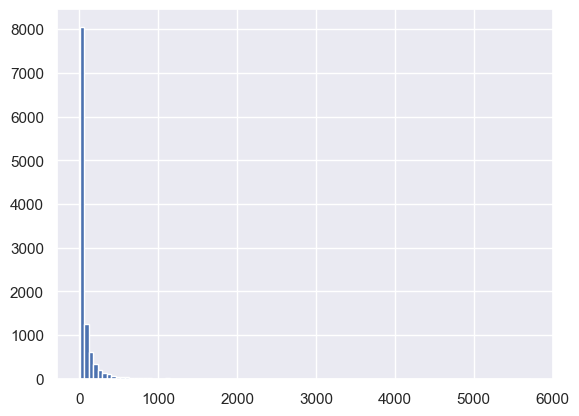

```python
ax = plt.hist(review_counts, bins=100)
```

# 2.

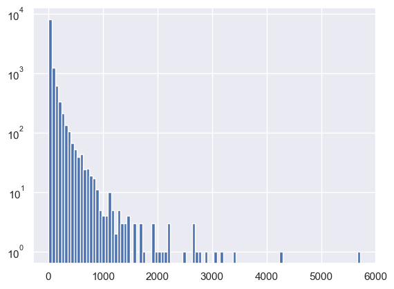

```python
ax = plt.hist(review_counts, bins=100, log=True)
```

# 3.

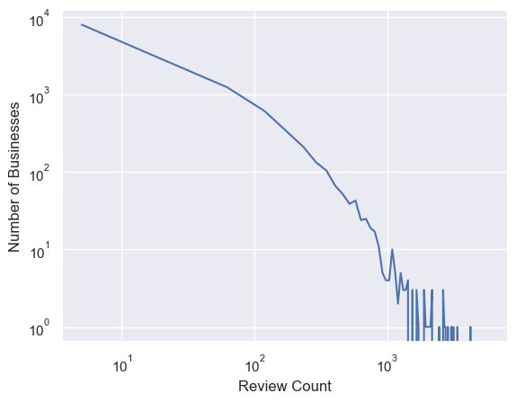

```python
interval_size = (max(review_counts) - min(review_counts)) / 100
intervals = [min(review_counts) + i * interval_size for i in range(100)]

# Count the number of businesses with review counts in each interval
counts = []
for interval in intervals:
  count = len([review_count for review_count in review_counts if review_count >= interval and review_count < interval + interval_size])
  counts.append(count)

# Plot the counts on a log-log scale
plt.loglog(intervals, counts)

# Label the axes
plt.xlabel('Review Count')
plt.ylabel('Number of Businesses')

# Show the plot
plt.show()
```

# 4.

# A.

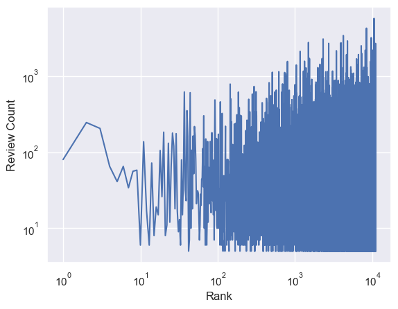

```python
# Rank the review counts
ranks = range(1, len(review_c)+1)

# Plot the review counts on a log-log scale
plt.loglog(ranks, review_c)

# Label the axes
plt.xlabel('Rank')
plt.ylabel('Review Count')

# Show the plot
plt.show()
```

# B.

```python
dfe.dtypes
```

[output not shown]

```python
dfe['date'].shape
```

```
(895311,)
```

```python
print(dfe['date'][0])
print(dfe['date'][895310])
print(dfe['date'][895309]) #paratirume oti den ine taksinomimenes ara prepi na ta taksinomisoume
```

```
2012-01-03 15:28:18
2018-03-13 13:54:48
2012-10-21 04:08:40
```

```python
dfe['date'] = pd.to_datetime(dfe['date'])
dfe.sort_values(by='date', inplace=True)
print(dfe['date'].head(10))
print(dfe['date'].tail(10))
```

```
630915   2005-02-16 04:06:26
282687   2005-05-25 01:12:54
189759   2005-05-26 04:09:08
281972   2005-05-26 04:20:21
632096   2005-05-26 04:28:58
461248   2005-05-26 04:41:09
190181   2005-06-22 22:34:40
462318   2005-06-24 22:46:33
284358   2005-06-24 23:03:52
375848   2005-06-24 23:27:54
Name: date, dtype: datetime64[ns]
718905   2022-01-19 18:44:37
180595   2022-01-19 18:44:37
184485   2022-01-19 18:55:37
795506   2022-01-19 19:01:59
89337    2022-01-19 19:03:21
362732   2022-01-19 19:08:26
895101   2022-01-19 19:09:39
629547   2022-01-19 19:26:37
360160   2022-01-19 19:42:20
629524   2022-01-19 19:46:34
Name: date, dtype: datetime64[ns]
```

```python
dfe['month']= dfe['date'].dt.month
```

```python
g = dfe.groupby(pd.Grouper(key='date', freq='M'))
# groups to a list of dataframes with list comprehension
dfs = [group for _,group in g]
```

```python
dfe.dtypes
```

```
review_id              object
user_id                object
business_id            object
stars                 float64
useful                  int64
funny                   int64
cool                    int64
text                   object
date           datetime64[ns]
month                   int64
dtype: object
```

```python
from scipy import stats as st

results = []
conf = []
for i in range(len(dfs)):
    results.append(dfs[i]['stars'].mean())
    conf.append(st.t.interval(confidence=0.95, df=len(dfs[i]['stars'])-1,
                loc=np.mean(dfs[i]['stars']),
                scale=st.sem(dfs[i]['stars'])))
```

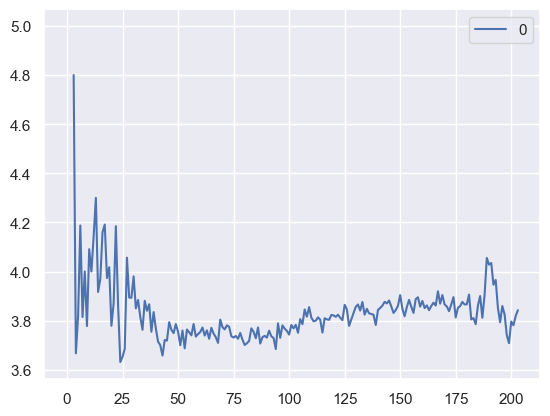

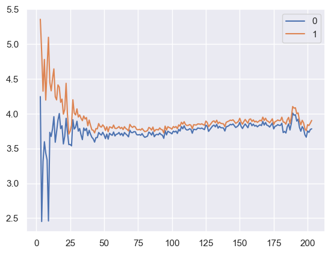

```python
dft = pd.DataFrame(conf)
df = pd.DataFrame(results)
df.plot()
dft.plot()
plt.show()
```

```python
dfe['date'] = pd.to_datetime(dfe['date'],infer_datetime_format=True)

dfe = dfe[(dfe['date'] <= pd.to_datetime('2010-02-16'))]
```

```python
dfe['date'].tail()
```

```
854700   2010-02-15 23:39:40
73989    2010-02-15 23:43:38
576855   2010-02-15 23:44:40
131050   2010-02-15 23:51:49
758127   2010-02-15 23:58:19
Name: date, dtype: datetime64[ns]
```

```python
g = dfe.groupby(pd.Grouper(key='date', freq='M'))
# groups to a list of dataframes with list comprehension
dfs = [group for _,group in g]
```

```python
len(dfs)
```

```
61
```

```python
results = []
conf = []
for i in range(len(dfs)):
    results.append(dfs[i]['stars'].mean())
    conf.append(st.t.interval(confidence=0.95, df=len(dfs[i]['stars'])-1,
              loc=np.mean(dfs[i]['stars']),
              scale=st.sem(dfs[i]['stars'])))
```

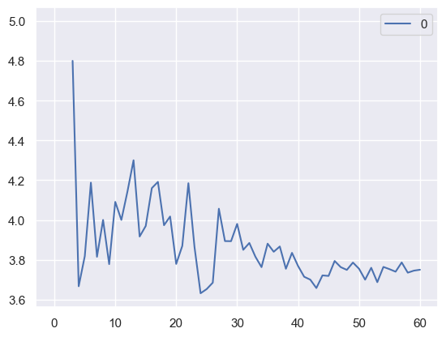

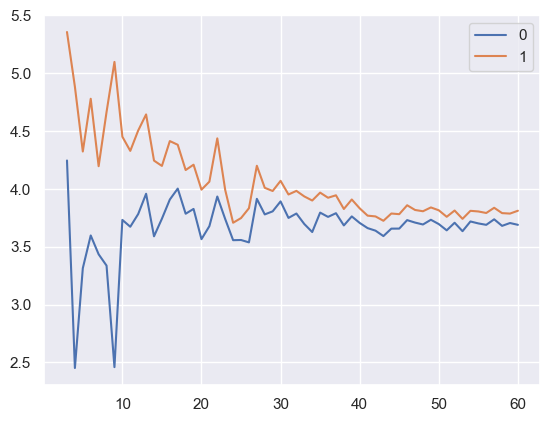

```python
df = pd.DataFrame(results)
dft = pd.DataFrame(conf)
df.plot()
dft.plot()
plt.show()
```

# Παρατηρούμε ότι το δευτερό γραφήμα είναι υποσύνολο του πρώτου γραφήματος οπώς και ήταν ανεμενόμενο γιατί περιορίσαμε τις εγγραφές το πολύ 5 χρόνια μετά το πρώτο review